# Clase_7_ST

Javier López

6/5/2020

## **Cointegración**

Las raices unitarias juegan un rol importante en el analisis de series temporales. Los procesos $k-dimensionales$ que hemos discutido hasta el momento han sido estacionarias o contienen $k$ raices unitarias. Ahora, esta situación no siempre puede ser así, por esta razón vamos a discutir estos casos en esta sección.  
Decimos que un proceso integrado de orden uno $I(1)$ si la primera diferencia de $Y_t$ es estacionario. Si la serie de tiempo es estacionaria, se dice que es $I(0)$.

### **Regresión Espuria**

Un ejemplo típico de una relación espuria puede ser la venta de helados en una ciudad. La tasa de ventas puede ser más alta cuando el sofocamiento es mayor. Plantear que la venta de helados causa los sofocamientos, estaría implicando una relación espuria entre las dos. En realidad, una ola de calor puede haber causado ambas. La ola de calor es un ejemplo de una variable escondida.

En el contexto de la economia, sea el modelo de regresión lineal clasico que es usado para formar la base de pronósticos macroeconómicos y modelos de simulación como sigue:

$$y_t = \beta_1x_{t,1}+\beta_2x_{t,2}+...+\beta_kx_{t,k}+ \epsilon_t$$
para $t = 1,...,T$, donde $y_t$ es la variable endogena, $\mathbf{x_t}^´=(x_{t,1},x_{t,2},...,x_{t,k})$ son las variables exogenas y $\epsilon_t$ es el error aleatorio. Asumimos para esta clase de modelos la estacionariedad de las variables. La inferencia de los coeficientes es las misma independiente del método empleado, sin embargo, es diferente en el caso de datos estacionarios diferenciados. En este caso, el término de error a menudo está altamente correlacionado y las estadísticas $t$ y $F$ están distorsionadas de tal manera que la hipótesis nula se rechaza con demasiada frecuencia para un valor crítico dado, por lo tanto, existe el riesgo de una *regresión espuria* o *regresión sin sentido*. Además, tales regresiones se caracterizan por un alto $R^2$. Este hecho surge porque la variable endógena contiene una tendencia estocástica y la variación total se calcula como $\sum_{t = 1}^T(y_t − \bar{y})$ es decir, se supone erróneamente que la serie tiene una media fija. Por lo tanto, la fórmula para calcular el $R^2$ no ajustado dado por:
$$R^2=1-\dfrac{\sum_{t=1}^T\hat{\epsilon}_t^2}{\sum_{t=1}^T(y_t − \bar{y})^2}$$
esta medida de bondad de ajuste tiende a la unidad a medida que el denominador se vuelve muy grande porque se coloca un gran peso en las observaciones extremas a ambos lados de la media $\bar{y}$.
Para evitar una regresión espuria, siempre se debe verificar la estacionariedad de los residuos cuando es probable que tanto la variable dependiente como los regresores de una regresión lineal sean de raíz unitaria no estacionaria. Para la regresión lineal simple, se puede emplear el modelo de regresión lineal con errores de series de tiempo para hacer inferencia con respecto a $\beta$.
Desde el punto de vista estadístico, el problema de la regresión espuria podría evitarse tomando las primeras diferencias de las variables $I(1)$ en la ecuación de regresión y usándolas en su lugar. Sin embargo, al aplicar este procedimiento, se incurre en dos problemas nuevos:
**Primero**, la diferenciación atenúa en gran medida la autocorrelación residual positiva grande; por lo tanto, se pueden extraer inferencias falsas sobre los coeficientes en la ecuación de regresión.
**En segundo lugar**, la mayoría de las teorías económicas se expresan en niveles, y se deducen las implicaciones de las relaciones a largo plazo entre las variables. Por lo tanto, estar obligado a utilizar enfoques de regresión con variables diferenciadas sería un gran obstáculo en la prueba de las teorías económicas.
Se han logrado con éxito otros medios para transformar datos no estacionarios en datos estacionarios (por ejemplo, mediante la construcción de relaciones logarítmicas). La razón por la cual tal transformación es adecuada para lograr la estacionariedad es que las no estacionarias se están “cancelando” entre sí, aunque esto no debe ser cierto en todos los casos y en todas las circunstancias.
En general, se requiere un nuevo enfoque para tratar las variables de tendencia en el contexto del análisis de regresión.

#### **Ejemplo de simulación de regresión espuria**

Simulamos dos caminatas aleatorias con diferenciación y regresivas una con otra, como se puede ver en la variable *sr.reg*.

```r
### Regresión espurea
library(lmtest)
```

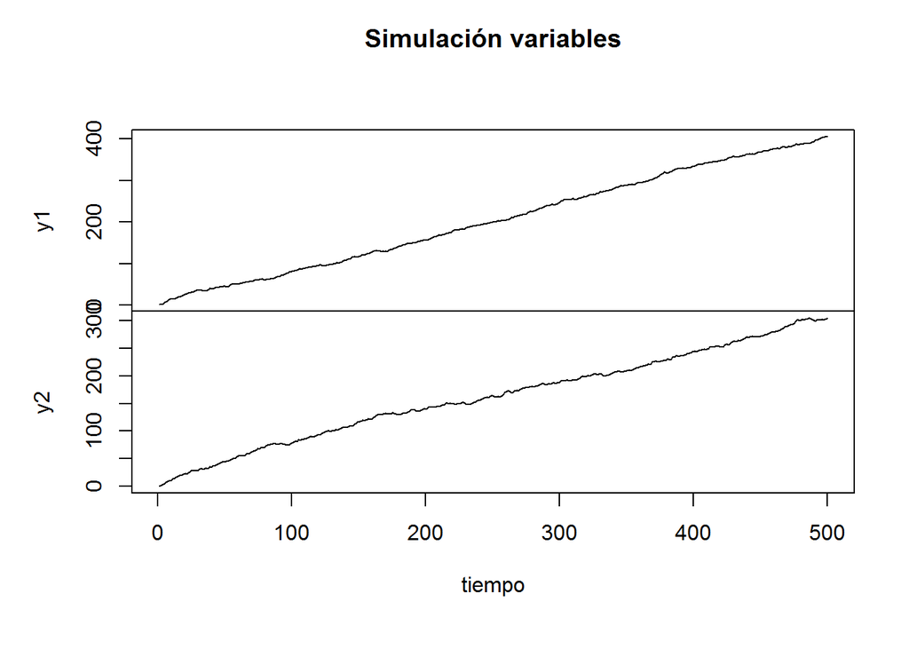

```r
set.seed(123456)
e1  <- rnorm(500)
e2  <- rnorm(500)
trd <- 1:500
y1  <- 0.8*trd + cumsum(e1)
y2  <- 0.6*trd + cumsum(e2)
plot.ts(cbind(y1, y2), main = 'Simulación variables', xlab = 'tiempo')
```

```r
sr.reg <- lm(y1 ~ y2)
summary(sr.reg)
```

```
##
## Call:
## lm(formula = y1 ~ y2)
##
## Residuals:
##      Min       1Q   Median       3Q      Max
## -30.6541 -11.5262   0.3589  11.1423  31.0058
##
## Coefficients:
##               Estimate Std. Error t value Pr(>|t|)
## (Intercept) -29.326969   1.367155  -21.45   <2e-16 ***
## y2            1.440787   0.007519  191.62   <2e-16 ***
## ---
## Signif. codes:  0 '***' 0.001 '**' 0.01 '*' 0.05 '.' 0.1 ' ' 1
##
## Residual standard error: 13.71 on 498 degrees of freedom
## Multiple R-squared:  0.9866, Adjusted R-squared:  0.9866
## F-statistic: 3.672e+04 on 1 and 498 DF,  p-value: < 2.2e-16
```

```r
sr.dw  <- dwtest(sr.reg)
sr.dw
```

```
##
##  Durbin-Watson test
##
## data:  sr.reg
## DW = 0.017153, p-value < 2.2e-16
## alternative hypothesis: true autocorrelation is greater than 0
```

Dado que es un modelo de regresión, se espera que el $R^2$ es cercano a $1$, y el test de Durbin-Watson ($H_0:$ errores no correlacionados) tiene un p-valor cercano a $0$.

### **Concepto de cointegración y modelos de corrección de errores**

La idea detrás de la cointegración es encontrar una combinación lineal entre dos variables $I(d)$ que produzca una variable con un orden inferior de integración.  
Más formalmente, la cointegración se define como sigue:  
Las componentes del vector $X_t$ se dicen cointegrados de orden $d,b$, denotado como $X_t\sim CI(d,b)$, si:  
**a)** todas las componentes de $X_t$ son $I(d)$  
**b)** un vector $(\beta\neq 0)$ existe tal que $\mathbf{W_t}=\beta^´X_t\sim I(d-b)$, $b>0$.  
El vector $\beta$ es llamado vector de cointegración.

El gran interés en este desarrollo entre los economistas se explica principalmente por el hecho de que ahora es posible detectar relaciones estables a largo plazo entre variables no estacionarias. Considere el caso de $d = 1, b = 1$; es decir, los componentes en el vector $X_t$ están todos integrados de orden uno, pero si existe una combinación lineal $\beta$ de estos, entonces la serie resultante $W_t$ es estacionaria.

Aunque las series individuales no son estacionarias, están unidas entre sí por el vector de cointegración. Ahora, la pregunta es cómo estimar el vector de cointegración $\beta$ y cómo modelar el comportamiento dinámico de las variables $I(d)$ en general y con fines de exposición de las variables $I(1)$ en particular.

Si $W_t$ es una serie estacionaria (es decir, las variables están cointegradas) se puede probar, por ejemplo, con la prueba *Dickey-Fuller (DF)* o la prueba *aumentada Dickey-Fuller (ADF)*, ósea una vez que la hipótesis nula de una raíz unitaria en la serie $W_t$ ha sido rechazada, sigue la especificación de un *modelo de corrección de errores (ECM)*. El *ECM* establece los cambios en $Y_t$ que se explican por su propia historia, los cambios rezagados de $X_t$ y el error del equilibrio a largo plazo en el período anterior.

$$\begin{align*}
\Delta y_t &= \psi_0 + \gamma_1 \hat{z}_{t-1}+\sum_{i=1}^K\psi_{1,i}\Delta x_{t-i}+\sum_{i=1}^L\psi_{2,i}\Delta y_{t-i} + \epsilon_{1,t}\\
\Delta x_t &= \xi_0 + \gamma_2 \hat{z}_{t-1} +\sum_{i=1}^K\xi_{1,i}\Delta y_{t-i}+\sum_{i=1}^L\xi_{2,i}\Delta x_{t-i} + \epsilon_{2,t}
\end{align*}$$

Se puede concluir del *ECM* y la regresión estática, en el caso de dos variables cointegradas $I(1)$, la causalidad de Granger debe existir en al menos una dirección. Es decir, al menos una variable puede ayudar a pronosticar la otra.

### **Ejemplo de simulación de cointegración**

Se crearon dos caminatas aleatorias, con la siguiente configuración $y_2 = 0.6 * y_1 + e_2$, donde $e_2$ es un proceso de ruido blanco. Por lo tanto, el vector cointegrante es $(1, −0.6)$.

```r
### Cointegración
set.seed(123456)
e1 <- rnorm(100)
e2 <- rnorm(100)
y1 <- cumsum(e1)
y2 <- 0.6 * y1 + e2
lr.reg <- lm(y2 ~ y1)
summary(lr.reg)
```

```
##
## Call:
## lm(formula = y2 ~ y1)
##
## Residuals:
##      Min       1Q   Median       3Q      Max
## -2.44465 -0.66254  0.03931  0.83827  2.04555
##
## Coefficients:
##             Estimate Std. Error t value Pr(>|t|)
## (Intercept)  0.03785    0.13477   0.281    0.779
## y1           0.58112    0.02138  27.186   <2e-16 ***
## ---
## Signif. codes:  0 '***' 0.001 '**' 0.01 '*' 0.05 '.' 0.1 ' ' 1
##
## Residual standard error: 0.985 on 98 degrees of freedom
## Multiple R-squared:  0.8829, Adjusted R-squared:  0.8817
## F-statistic: 739.1 on 1 and 98 DF,  p-value: < 2.2e-16
```

Primero, la ecuación de largo plazo *lr.reg* ha sido estimada por MCO. Dado un tamaño de muestra de $100$, como se esperaba, el coeficiente estimado del regresor $y_1$ está cerca de su contraparte teórica al tener un valor de $0.5811$.

```r
error  <- residuals(lr.reg)
error.lagged <- error[-c(99, 100)]
```

El error de equilibrio se almacena como *error*, y su versión retrasada se ha creado simplemente soltando las dos últimas entradas.

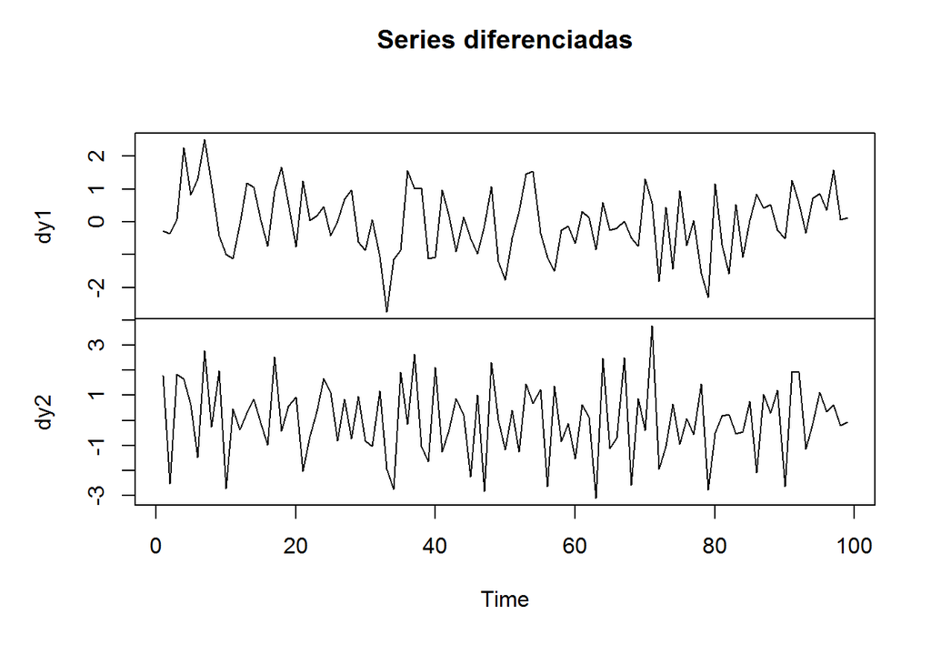

```r
dy1 <- diff(y1)
dy2 <- diff(y2)
plot.ts(cbind(dy1, dy2), main = 'Series diferenciadas')
```

Debido a que las diferencias y las primeras diferencias rezagadas de $y_1$ y $y_2$ se generan con los comandos *diff()* y *embed()*, restar las dos últimas entradas de *error* es equivalente a retrasar el término de error una vez en la regresión del *ECM* resultante.

```r
diff.dat <- data.frame(embed(cbind(dy1, dy2), 2))
colnames(diff.dat) <- c('dy1', 'dy2', 'dy1.1', 'dy2.1')
head(diff.dat)
```

```
##           dy1        dy2       dy1.1      dy2.1
## 1 -0.35500184 -2.5179073 -0.27604777  1.7837118
## 2  0.08748742  1.8407098 -0.35500184 -2.5179073
## 3  2.25225573  1.6331811  0.08748742  1.8407098
## 4  0.83446013  0.6200382  2.25225573  1.6331811
## 5  1.31241551 -1.4668629  0.83446013  0.6200382
## 6  2.50264541  2.7717847  1.31241551 -1.4668629
```

Los resultados del *ECM* se muestra a continuación. No es sorprendente que el error de equilibrio del último período se haya resuelto casi por completo. Su coeficiente es significativo y cercano al negativo.

```r
ecm.reg <- lm(dy2 ~ error.lagged + dy1.1 + dy2.1, data = diff.dat)
summary(ecm.reg)
```

```
##
## Call:
## lm(formula = dy2 ~ error.lagged + dy1.1 + dy2.1, data = diff.dat)
##
## Residuals:
##     Min      1Q  Median      3Q     Max
## -2.9588 -0.5439  0.1370  0.7114  2.3065
##
## Coefficients:
##               Estimate Std. Error t value Pr(>|t|)
## (Intercept)   0.003398   0.103611   0.033    0.974
## error.lagged -0.968796   0.158554  -6.110 2.24e-08 ***
## dy1.1         0.808633   0.112042   7.217 1.35e-10 ***
## dy2.1        -1.058913   0.108375  -9.771 5.64e-16 ***
## ---
## Signif. codes:  0 '***' 0.001 '**' 0.01 '*' 0.05 '.' 0.1 ' ' 1
##
## Residual standard error: 1.026 on 94 degrees of freedom
## Multiple R-squared:  0.5464, Adjusted R-squared:  0.5319
## F-statistic: 37.74 on 3 and 94 DF,  p-value: 4.243e-16
```

### Ejemplo rendimientos de bonos corporativos

```r
#################################################################
#####                   Librerias utilizadas                #####
#################################################################

library(fUnitRoots)
library(urca)
library(MTS)
library(ggplot2)
library(readr)

#################################################################
#####                   Sistema de carpetas                 #####
#################################################################

inpath  <- "D:/PERSONAL/6. EDUCACIÓN/1-LIBERTADORES/1-SERIES DE TIEMPO/inpath/"
outpath <- "D:/PERSONAL/6. EDUCACIÓN/1-LIBERTADORES/1-SERIES DE TIEMPO/outpath/"

#################################################################
#####                   Carga de información                #####
#################################################################

m_bnd <- read_table2(paste(inpath, "m-bnd.txt", sep = ""), col_names = FALSE,
                     col_types = cols(X4 = col_number(), X5 = col_number()))
m_bnd.A <- ts(m_bnd[,4], start = c(1954, 7), frequency = 12)
m_bnd.B <- ts(m_bnd[,5], start = c(1954, 7), frequency = 12)
```

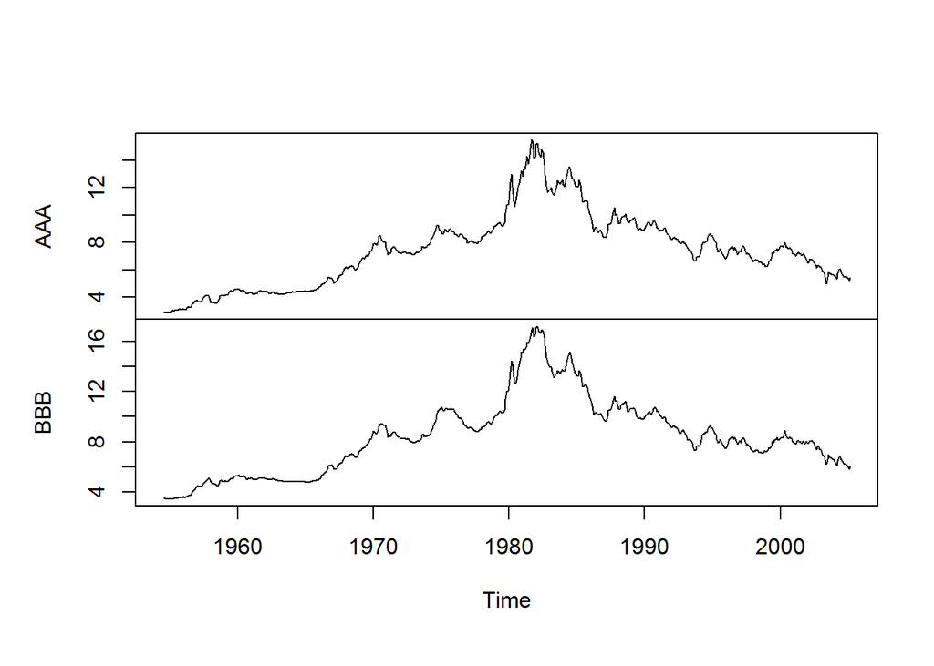

```r
#################################################################
#####                   Ejecución Programa                  #####
#################################################################

#bnd <- as.matrix(m_bnd[,4:5], ncol = 2)
bnd <- as.matrix(cbind(m_bnd.A, m_bnd.B), ncol = 2)
colnames(bnd) <- c("AAA","BBB")
plot.ts(bnd, main = '')
```

```r
adfTest(bnd[,1], lags=3, type="c")
```

```
##
## Title:
##  Augmented Dickey-Fuller Test
##
## Test Results:
##   PARAMETER:
##     Lag Order: 3
##   STATISTIC:
##     Dickey-Fuller: -1.7007
##   P VALUE:
##     0.425
##
## Description:
##  Fri May 08 16:01:45 2020 by user: usuario
```

```r
adfTest(bnd[,2], lags=2, type="c")
```

```
##
## Title:
##  Augmented Dickey-Fuller Test
##
## Test Results:
##   PARAMETER:
##     Lag Order: 2
##   STATISTIC:
##     Dickey-Fuller: -1.6221
##   P VALUE:
##     0.4544
##
## Description:
##  Fri May 08 16:01:45 2020 by user: usuario
```

Como se esperaba, las dos series se mueven de manera paralela. La prueba de raíz unitaria Dickey-Fuller aumentada confirma que los dos rendimientos de los bonos son raíz unitaria no estacionaria.  
Suponiendo que la serie bivariada de rendimiento de los bonos sigue un modelo VAR, aplicamos los criterios de información para especificar el orden.

```r
m1 <- VARorder(bnd)
datos.int  <- bnd
plot.crite <- data.frame(rbind(cbind(round(0:13,0), 'AIC', VARorder(datos.int)$aic),
                               cbind(round(0:13,0), 'BIC', VARorder(datos.int)$bic),
                               cbind(round(0:13,0), 'HQ', VARorder(datos.int)$hq)))
names(plot.crite) <- c('p', 'Criterio', 'Valores')
plot.crite$p       <- as.numeric(as.character(plot.crite$p))
plot.crite$Valores <- as.numeric(as.character(plot.crite$Valores))
```

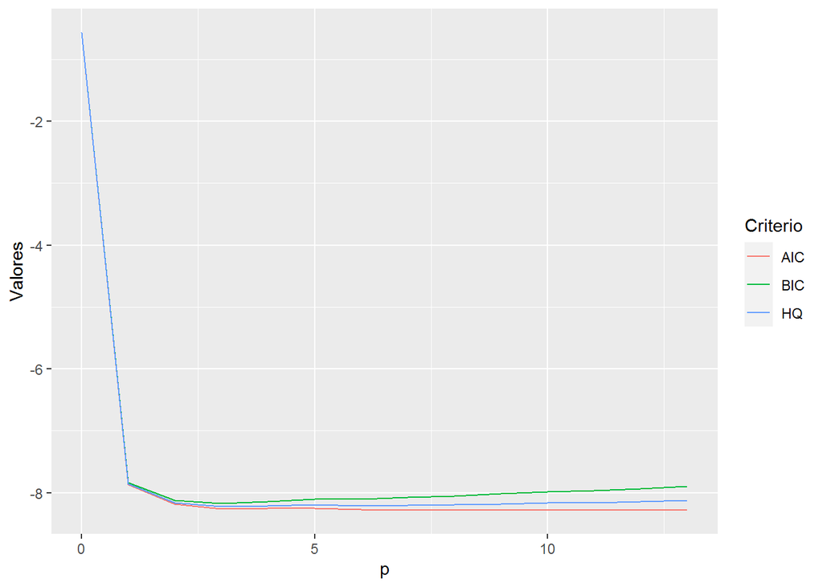

```r
ggplot(plot.crite, aes(x = p,y = Valores, group = Criterio)) +
  geom_line(aes(color = Criterio))
```

El orden $p=3$ es seleccionado por BIC y HQ. Emplearemos un modelo $VAR(3)$ en el test de cointegración.

```r
m2 <- ca.jo(bnd, K=2, ecdet=c("none"))
summary(m2)
```

```
##
## ######################
## # Johansen-Procedure #
## ######################
##
## Test type: maximal eigenvalue statistic (lambda max) , with linear trend
##
## Eigenvalues (lambda):
## [1] 0.054773196 0.004665298
##
## Values of teststatistic and critical values of test:
##
##           test 10pct  5pct  1pct
## r <= 1 |  2.84  6.50  8.18 11.65
## r = 0  | 34.19 12.91 14.90 19.19
##
## Eigenvectors, normalised to first column:
## (These are the cointegration relations)
##
##            AAA.l2    BBB.l2
## AAA.l2  1.0000000  1.000000
## BBB.l2 -0.8856789 -2.723912
##
## Weights W:
## (This is the loading matrix)
##
##            AAA.l2      BBB.l2
## AAA.d -0.04696894 0.002477064
## BBB.d  0.04046524 0.002139536
```

Los dos valores propios son $0.054773196$ y $0.004665298$, respectivamente.  
Si se utiliza la estadística de prueba *lambda max*, obtenemos que $L_{max}(1) = 2.84$ y $L_{max}(0) = 34.19$. En comparación con los valores críticos, rechazamos $r = 0$, pero no podemos rechazar $r = 1$. Por lo tanto, la matriz de $ECM$ es de rango $1$ y hay un vector de cointegración.

```r
m4 <- ca.jo(bnd, K=2, ecdet=c("none"), type=c("trace"), spec=c("transitory"))
summary(m4)
```

```
##
## ######################
## # Johansen-Procedure #
## ######################
##
## Test type: trace statistic , with linear trend
##
## Eigenvalues (lambda):
## [1] 0.054773196 0.004665298
##
## Values of teststatistic and critical values of test:
##
##           test 10pct  5pct  1pct
## r <= 1 |  2.84  6.50  8.18 11.65
## r = 0  | 37.03 15.66 17.95 23.52
##
## Eigenvectors, normalised to first column:
## (These are the cointegration relations)
##
##            AAA.l1    BBB.l1
## AAA.l1  1.0000000  1.000000
## BBB.l1 -0.8856789 -2.723912
##
## Weights W:
## (This is the loading matrix)
##
##            AAA.l1      BBB.l1
## AAA.d -0.04696894 0.002477064
## BBB.d  0.04046524 0.002139536
```

Si las estadísticas de seguimiento *lambda transitoria*, tenemos $L_{tr}(1) = 2.84$ y $L_{tr}(0) = 37.03$. Nuevamente, la hipótesis nula de una cointegración no es rechazada.

La serie de cointegración es $W_t = (1, −0.886) \mathbf{Y_t}$.

```r
wt <- bnd[,1] - 0.886*bnd[,2]
adfTest(wt, lags=3, type='c')
```

```
##
## Title:
##  Augmented Dickey-Fuller Test
##
## Test Results:
##   PARAMETER:
##     Lag Order: 3
##   STATISTIC:
##     Dickey-Fuller: -4.6054
##   P VALUE:
##     0.01
##
## Description:
##  Fri May 08 16:01:47 2020 by user: usuario
```

La prueba *Dickey-Fuller Aumentada* de $W_t$ confirma que la serie no tiene ninguna raíz unitaria. El estadístico de prueba es $−4.61$ con $p-valor= 0.01$.  
La figura muestra la serie cointegrada $W_t$. Como se esperaba, la serie muestra las características de una serie temporal estacionaria.

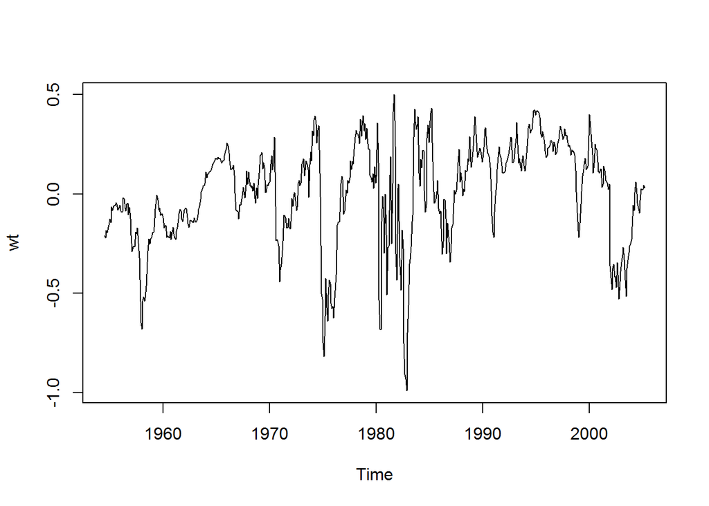

```r
wt <- ts(wt, start = c(1954, 7), frequency = 12)
plot.ts(wt)
```